# PROYECTO DE TESIS

Author

Griselida Rojas Campos

# 1 TITULO

Comportamiento agronómico, fisiológico y valor nutricional de cinco cultivares de coliflor (Brassica oleracea var. botrytis) bajo las condiciones edafoclimáticas de Chachapoyas, Amazonas.

# 2 PROBLEMA

La producción de coliflor en el Perú ha experimentado un crecimiento sostenido en los últimos años, impulsado por una mayor demanda tanto a nivel nacional como regional. La provincia de Chachapoyas tiene un gran potencial para el cultivo de coliflor, las condiciones climáticas favorables y la disponibilidad de suelos fértiles son factores claves que pueden contribuir al desarrollo de este cultivo. Sin embargo, la productividad de este cultivo no alcanza su máximo potencial debido a la falta de uso de prácticas agrícolas sostenibles, especialmente el uso de material genético moderno como el uso de híbridos, que en muchas ocasiones limitan el rendimiento. Esta situación representa una oportunidad para evaluar diferentes cultivares de coliflor e identificar aquellas que se adapten a las condiciones específicas de la región, lo que permitirá maximizar la producción y mejorar la rentabilidad de los agricultores locales. ¿Cuál será el comportamiento agronómico, fisiológico y el valor nutricional de cinco cultivares de coliflor (Brassica oleracea var botrytis) bajo las condiciones edafoclimáticas de Chachapoyas, Amazonas?

# 3 OBJETIVOS

## 3.1 OBJETIVO GENERAL

- Determinar el comportamiento agronómico, fisiológico y valor nutricional de cinco cultivares de coliflor (Brassica oleracea var. botrytis) bajo las condiciones edafoclimáticas de Chachapoyas, Amazonas.

## 3.2 OBJETIVOS ESPECÍFICOS

- Describir el comportamiento fenológico de cinco cultivares de coliflor bajo las condiciones edafoclimáticas de Chachapoyas, Amazonas.
- Evaluar los parámetros agronómicos de cinco cultivares de coliflor bajo las condiciones edafoclimáticas de Chachapoyas, Amazonas.
- Evaluar los parámetros fisiológicos de cinco cultivares de coliflor bajo las condiciones edafoclimáticas de Chachapoyas, Amazonas.
- Evaluar el valor nutricional de cinco cultivares de coliflor bajo las condiciones edafoclimáticas de Chachapoyas, Amazonas.

# 4 ANTECEDENTES DE LA INVESTIGACIÓN

Las Brassicas como la coliflor y brócoli (Brassica oleracea var. italica Plenck), comparten genes en común, en cuanto a su domesticación del brócoli silvestre se cree se realizó hace miles de años en el Mediterráneo oriental, y se logra expandir hacia China, para que posterior a ello en una medida de 500 años, se comenzó a seleccionar las variedades más comunes, que tengan una densa florescencia terminal blanca lo que origina a la coliflor y una inflorescencia verde menos compactada que viene a ser el brócoli (Ordás Pérez, 2001). Pese a diversos datos recopilados de informes de viajeros que aseguran haber encontrado la coliflor en estado salvaje en regiones inusuales, no hay una fuente verídica que asegure esto, y es poco confiable ya que en algunas de estas regiones no presentan el entorno climático idóneo para su desarrollo, además, el periodo de invierno en el este de Europa y Siberia son severos para su desarrollo, en la actualidad las principales áreas productivas a nivel mundial son en Long Island, Nueva York, California y el estado de Oregón (Mittell et al., 2020). Otros autores también hacen referencia de su origen Mediterráneo o Asia Menor a las peñas calcáreas de Inglaterra, a las costas de Dinamarca, a Francia y España. Inclusive hay referencias históricas anteriores a la era cristiana, la coliflor en un estado nativo o salvaje se encuentra en la superficie de rocas a orilla del mar, en islas como Laaland-Dinamarca, Heligoland- Inglaterra e Irlanda, Canal, Charente interior. Además, Sibthorp afirmó hallar este vegetal en el monte Athos, pero esto no fue confirmado por ningún científico botánico actualmente (Mabry et al., 2021). Si bien hay diversas variedades de este vegetal, la más notable es la coliflor blanca, con una inflorescencia de pequeños ramilletes comestibles, con una distribución similar al brócoli, su domesticación se atribuye a diversas afirmaciones, como los egipcios, griegos y romanos. Si bien en un principio este cultivo se concentró en la península de Italia y según la comercialización con Roma, esta se distribuye por el Mediterráneo, ya en el siglo XVI se extiende a Francia, en 1586 aparece en Inglaterra, en el siglo XVII se difunde por toda Europa, a finales del siglo XVIII a España y durante el siglo XIX Europa lo extiende a todo el mundo por medio de la colonización (Maggioni et al., 2010).

# 5 HIPÓTESIS

Al menos existe un cultivar de coliflor que se adapta de manera favorable a las condiciones edafoclimáticas de Chachapoyas, Amazonas.

# 6 METODOLOGÍA

## 6.1 Población, muestra y muestreo

### 6.1.1 Área de estudio.

La presente investigación se va a desarrollar en una parcela ubicada a espaldas de la Universidad Nacional Toribio Rodríguez de Mendoza, el distrito de Chachapoyas, provincia de Chachapoyas, región Amazonas (Perú) a una altitud de 2428 m.s.n.m y con las siguientes coordenadas geográficas de 6°13’35” S y 77°52’27” O.

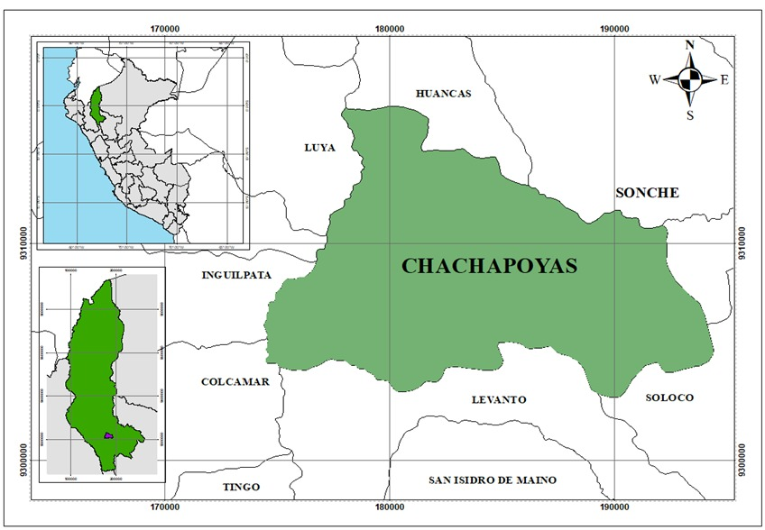

**Figura 1.** *ubicacion*

### 6.1.2 Población

La población de la investigación estará constituida por todas las plantas de coliflor de las distintas variedades que se van a cultivar bajo las condiciones climáticas de Chachapoyas.

### 6.1.3 Muestra

La muestra esta conformada por las plantas de cinco cultivares de coliflor seleccionados para la investigación. Se trabajará con un total de 20 unidades experimentales, resultado de 5 tratamientos por 4 repeticiones cultivadas en un área total de 394.45 m2.

### 6.1.4 Muestreo

se empleará un muestreo aleatorio sistemático dentro de cada unidad experimental. Para las evaluaciones se seleccionará de forma aleatoria 10 plantas de los surcos intermedios de cada unidad experimental, las cuales serán marcadas y monitoreadas.

## 6.2 Variables de estudio

### 6.2.1 Variable independiente

- Cinco cultivares de coliflor
- Condiciones edafoclimáticas de Chachapoyas

### 6.2.2 Variable dependiente

**Variables morfológicas y fenológicas**

- Número de hojas
- Altura de plantas
- Días al inicio de la floración
- Días a la cosecha

**Variables agronómicas**

- % de germinación
- % de prendimiento
- Diámetro de la pella
- Peso de la pella
- Rendimiento de pella

**Variables fisiológicas**

- Fotosíntesis neta
- Fluorescencia de la clorofila
- Contenido de clorofila a y b
- Contenido de carotenoides totales

**Variables nutricionales de la pella**

- Materia seca
- Contenido total de aminoácidos
- Contenido total de proteínas
- Contenido total de azúcares
- Contenido total de almidón
- Contenido total de compuestos fenólicos

## 6.3 Metodos

### 6.3.1 Semilla de coliflor

Las semillas serán obtenidas de distribuidores autorizados. A continuación, se muestran los nombres de los cultivares de coliflor que serán utilizados en el estudio.

**Tabla 1.** Cultivares de coliflor que se utilizarán en la investigación

[output not shown]

### 6.3.2 Diseño de la investigación

**Tabla 2.** Descripción de los tratamientos.

| Tratamiento | Cultivar |
| --- | --- |
| T1 | Cultivar 1 |
| T2 | Cultivar 2 |
| T3 | Cultivar 3 |
| T4 | Cultivar 4 |
| T5 | Cultivar 5 |

[figure not shown]

**Figura 2.** Diseño de investigación

### 6.3.3 Modelo aditivo lineal

$Yᵢⱼ = μ + τᵢ + βⱼ + εᵢⱼ$

### 6.3.4 Diseño del campo experimental

**Tabla 3.** Diseño del campo experimental.

| Categoría | Descripción | Valor |
| --- | --- | --- |
| Área experimental | Largo del área experimental | 24.5 m |
| Área experimental | Ancho del área experimental | 16.1 m |
| Área experimental | Área total del área experimental | 394.45 m² |
| Unidad experimental (UE) | Número de UE | 20 |
| Unidad experimental (UE) | Largo de la UE | 4.5 m |
| Unidad experimental (UE) | Ancho de la UE | 3.5 m |
| Unidad experimental (UE) | Área neta de la UE | 15.75 m² |
| Bloques | Número de bloques | 4 |
| Bloques | Largo | 24.5 m |
| Bloques | Ancho | 3.5 m |
| Bloques | Distancia entre bloques | 0.7 m |
| Surcos | Número de surcos por UE | 5 |
| Surcos | Largo de los surcos | 4.5 m |
| Surcos | Distanciamiento entre surcos | 0.7 m |
| Calles | Ancho de las calles entre cada UE | 0.5 m |
| Calles | Ancho de las calles de cada bloque | 0.7 m |

### 6.3.5 Manejo agronómico

#### 6.3.5.1 Análisis de suelo

Se realizará un análisis de suelo el cual es de suma importancia para poder conocer su pH, el porcentaje de materia orgánica y la cantidad de nitrógeno, potasio y fósforo que contiene donde se va a establecer el cultivo.

#### 6.3.5.2 Preparación del terreno

Se realizará mediante el arado del suelo, desmenuzado de terrones y la nivelación del suelo y la preparación de los surcos para realizar el sembrado.

#### 6.3.5.3 Siembra de almácigo

Se sembrará las semillas en unas 9 bandejas de germinación aproximadamente los cinco cultivares de coliflor.

#### 6.3.5.4 Trasplante de plántulas

El trasplante se realizará una vez que las plántulas tengan un tamaño adecuado para que pueda soportar las condiciones de campo.

#### 6.3.5.5 Fertilización

Se realizará una fertilización de base que es junto con la siembra y una complementaria, en función a un análisis de suelo previo y según el requerimiento del cultivo de coliflor.

#### 6.3.5.6 Riego

Se aplicará un riego constante para facilitar la germinación y el establecimiento del cultivo.

#### 6.3.5.7 Control de malezas

Se realizará el control de malezas de manera manual haciendo el uso de una lampa o en todo caso de un sable o machete.

#### 6.3.5.8 Control fitosanitario

Al ser la coliflor susceptible a varias plagas se realizará un monitoreo constante para evitar que se vea afectada por ellas y colocar trampas o hacer uso de químicos para el control de las plagas.

#### 6.3.5.9 Cosecha

La cosecha se realizará una vez que el cultivo alcance el tamaño adecuado y la madurez que indique que se encuentra apta para su cosecha.

### 6.3.6 Evaluación de variables

#### 6.3.6.1 Evaluación de las variables morfológicas y fenológicas

1. Número de hojas

El número de hojas a evaluar se tomarán de las 10 plantas seleccionadas al azar y las cuales serán evaluadas.

2. Altura de plantas

La altura de las plantas será medida desde la base hasta el ápice de la planta, se realizará la medida de las 10 plantas seleccionadas del surco medio de cada unidad experimental.

3. Días al inicio de la floración

Se realizará la evaluación de los cultivares desde el inicio de la floración hasta la cosecha.

4. Días a la cosecha

Se evaluará los días transcurridos desde el trasplante de las plántulas al campo hasta el momento en que las pellas alcanzan el tamaño y capacidad comercial adecuada para la cosecha.

#### 6.3.6.2 Evaluación de las variables agronómicas

1. % de germinación

Se evaluará en las bandejas de germinación la cantidad de semillas que germinaran después de la siembra.

2. % de prendimiento

Se evaluará en campo la cantidad de plántulas que sobrevivieron en cada unidad experimental y se comparará con el número total trasplantado.

3. Diámetro de la pella

Se medirá con una cinta métrica el diámetro transversal máximo de la pella, en el momento de la cosecha. Se tomarán mediciones en 10 plantas representativas por unidad experimental.

4. Peso de la pella

Se determinará el peso de cada pella cosechada usando una balanza electrónica. Se evaluarán 10 pellas por unidad experimental. El valor se expresará en gramos o kilogramos, según el rango obtenido, y se calculará el promedio por tratamiento.

5. Rendimiento de pella

El rendimiento se estimará aplicando el resultado que se obtendrá en una muestra pequeña a una escala mayor como una hectárea.

### 6.3.7 Cronograma

| Etapas | Duración | Inicio | Fin |
| --- | --- | --- | --- |
| Revisión y aprobación del proyecto. | 20 días | 19/05/2025 | 07/06/2025 |
| Elaboración del informe. | 1 mes | 08/06/2025 | 08/07/2025 |
| Revisión y corrección del informe. | 1 mes | 09/07/2025 | 09/08/2025 |
| Establecimiento de la parcela, evaluación de variables y recolección de datos. | 10 meses | 14/06/2025 | 14/04/2026 |
| Análisis de datos. | 1 mes | 15/04/2026 | 15/05/2026 |
| Elaboración del informe final. | 1 mes | 16/05/2026 | 16/06/2026 |
| Presentación y sustentación. | — | — | — |

Nota: Fechas de cada etapa de duración del proyecto, desde el inicio hasta la finalización del proyecto de investigación.

## 6.4 Analisis de datos

Los datos obtenidos correspondientes a las variables agronómicas, fisiológicas y nutricionales serán sometidos a un análisis de varianza (ANOVA) utilizando un software estadístico como R, bajo un diseño de bloques completamente al azar (DBCA), se aplicará la prueba de Tukey al 5% de probabilidad.

# 7 REFERENCIAS BIBLIOGRAFICAS

- FAO. (2020). Crop diversification in Malasya—Tunku Mahmud Bin Tunku Yahya. Food and Agriculture Organization of the United Nations. https://www.fao.org/4/x6906e/x6906e08.htm
- Flores, H. E., Ojeda, G. R., Medina, G., & Ramirez, G. (2020). Requerimientos agroecológicos de cultivos.
- García, C. A. R. (2010). Identificación de plagas y enfermedades en el cultivo de crucíferas Brócolo (Brassica oleraceae l.
- Index Box. (2025). Worldwide Cauliflower and Broccoli Market to See Steady Growth with +0.9% CAGR Expected from 2024 to 2035. World - Cauliflower And Broccoli - Market Analysis, Forecast, Size, Trends and Insights. https://www.indexbox.io/blog/cauliflower-and-broccoli-world-market-overview- 2024-1/
- INEI. (2024a). Compendio Estadístico Departamento de Amazonas 2024. Instituto Nacional de Estadística e Informática.
- INEI. (2024b). Tomo-2-peru-compendio-estadistico-2024. Instituto Nacional de Estadística e Informática.
- Mabry, M. E., Turner-Hissong, S. D., Gallagher, E. Y., McAlvay, A. C., An, H., Edger, P. P., Moore, J. D., Pink, D. A. C., Teakle, G. R., Stevens, C. J., Barker, G., Labate, J., Fuller, D. Q., Allaby, R. G., Beissinger, T., Decker, J. E., Gore, M. A., & Pires, J. C. (2021). The Evolutionary History of Wild, Domesticated, and Feral Brassica oleracea (Brassicaceae). Molecular Biology and Evolution, 38(10), 4419-4434. https://doi.org/10.1093/molbev/msab183
- Maggioni, L., Von Bothmer, R., Poulsen, G., & Branca, F. (2010). Origin and Domestication of Cole Crops (Brassica oleracea L.): Linguistic and Literary Considerations1. Economic Botany, 64(2), 109-123. https://doi.org/10.1007/s12231-010-9115-2
- Mittell, E. A., Cobbold, C. A., Ijaz, U. Z., Kilbride, E. A., Moore, K. A., & Mable, B. K. (2020). Feral populations of Brassica oleracea along Atlantic coasts in western Europe. Ecology and Evolution, 10(20), 11810-11825. https://doi.org/10.1002/ece3.6821
- Ordás Pérez, A. (2001). Coliflor. Sociedad Española de Ciencias Hortícolas. https://digital.csic.es/handle/10261/166918
- Romero, M., & Pérez, M. (2024). Optimizing Brassica oleracea L. Breeding Through Somatic Hybridization Using Cytoplasmic Male Sterility (CMS) Lines: From Protoplast Isolation to Plantlet Regeneration. Plants, 13(22), Article 22. https://doi.org/10.3390/plants13223247
- Scienceagri. (2022). 10 World’s Largest Country Producers of Cauliflowers and Broccoli. The Science Agriculture. https://www.scienceagri.com/2023/11/10- worlds-largest-producers-of.html
- World Population. (2025). Broccoli Production by Country 2025. World Population Review. https://worldpopulationreview.com/country-rankings/broccoli- production-by-country